# **Class 11: Terrorism and Weapons of Mass Destruction**<sup>1</sup>

## **Introduction**

As a result of the events of 9/11, as well as the ongoing accounts of acts of terrorism in the media, we have seen rising national concerns about terrorists using sophisticated weapons (LaFree, Dugan, & Miller., 2015, p. 99). In response to these concerns, the U.S. government has invested more resources in counterterrorism measures, shifting the focus of the FBI from traditional crimes to counterterrorism after 9/11 (LaFree, Dugan, & Miller, 2015, p. 5). Beyond internal measures, Saddam Hussein’s association with terrorists and the threat of weapons of mass destruction (WMDs) were the main reasons given in the rationale for the invasion of Iraq in 2003 (Otterman, 2003). An ongoing international concern is the damage terrorists could cause if they obtain weapons of mass destruction (WMD) (NATO, 2015). However, the definition of a WMD is unclear (Kaszeta, 2014), so we will look at a more specific group of weapons with the capacity to cause significant damage: **chemical, biological, radiological**, and **nuclear weapons**, denoted, **CBRN**.

In this activity, we will study the extent to which CBRN weapons have been used, and analyze whether or not their past use fits with our perceptions. We will attempt to answer questions such as *have CBRN weapons been used successfully in the past*?; *which weapons are more historically dangerous* (measured by the number of fatalities and injuries) *in the hands of terrorists*, common weapons like firearms and explosives, or advanced weapons like chemical, biological, and nuclear weapons?; and w*hat are the implications of past usage of CBRN weapons compared to other weapons in determining our priorities in counter-terrorism policies*?

In this handout, we will use the [Global Terrorism Database](http://www.start.umd.edu/gtd) (GTD). The GTD contains information about more than 140,000 terrorist incidents occurring between 1970 and 2018.<sup>2</sup> The data in the GTD are gathered only from incidences that are reported in the media. The team managing the database verifies the information they gather through multiple news sources (LaFree, Dugan, & Miller, 2015).

## **Using Summary Statistics and Simple Plots to Identify Key Events**

We start by reading in a simplified version of the full Global Terrorism Database downloaded April 26 2019:

```r
GTDdata <- read.csv("/usr/share/R/library/Stat324/Data/GT2019.csv")

# View the first 5 rows of each column
kable(head(GTDdata)) %>%
  kable_styling(bootstrap_options = c("striped", "hover", "condensed", "responsive"), full_width = F, position = "left")
```

| Year | Month | Day | Country | Region | provstate | latitude | longitude | AttackType | TargetType | claimed | WeaponType | Fatalities | Wounded | Success |
| --- | --- | --- | --- | --- | --- | --- | --- | --- | --- | --- | --- | --- | --- | --- |
| 1986 | 3 | 27 | Australia | East Asia & Pacific | Victoria | -37.81319 | 144.9630 | Bombing | Armed Forces | NA | Explosives | 0 | 21 | 1 |
| 1988 | 5 | 3 | New Caledonia | East Asia & Pacific | Sud | -22.27580 | 166.4580 | Assassination | Armed Forces | NA | Explosives | 0 | 0 | 1 |
| 1988 | 7 | 18 | Australia | East Asia & Pacific | Australian Capital Territory | -35.30824 | 149.1242 | Assassination | Armed Forces | NA | Explosives | 0 | 0 | 1 |
| 1988 | 12 | 21 | Australia | East Asia & Pacific | South Australia | -34.92873 | 138.5999 | Bombing | Armed Forces | NA | Explosives | 0 | 0 | 1 |
| 1991 | 9 | 16 | New Zealand | East Asia & Pacific | Canterbury | -43.53205 | 172.6362 | Bombing | Armed Forces | NA | Explosives | 0 | 0 | 1 |
| 1980 | 12 | 17 | Australia | East Asia & Pacific | New South Wales | -33.87365 | 151.2069 | Assassination | Armed Forces | NA | Firearms | 2 | 0 | 1 |

```r
# View the structure of each column
str(GTDdata, max.level = 2)
```

```
## 'data.frame':    191464 obs. of  15 variables:
##  $ Year      : int  1986 1988 1988 1988 1991 1980 1984 1988 1988 1988 ...
##  $ Month     : int  3 5 7 12 9 12 12 2 4 4 ...
##  $ Day       : int  27 3 18 21 16 17 5 22 22 27 ...
##  $ Country   : Factor w/ 205 levels "Afghanistan",..: 9 126 9 9 128 9 126 126 126 126 ...
##  $ Region    : Factor w/ 7 levels "East Asia & Pacific",..: 1 1 1 1 1 1 1 1 1 1 ...
##  $ provstate : Factor w/ 2580 levels "","A Coruna",..: 2431 2210 166 2160 397 1585 1607 1607 2210 2210 ...
##  $ latitude  : num  -37.8 -22.3 -35.3 -34.9 -43.5 ...
##  $ longitude : num  145 166 149 139 173 ...
##  $ AttackType: Factor w/ 8 levels "Armed Assault",..: 3 2 2 3 3 2 2 6 1 6 ...
##  $ TargetType: Factor w/ 8 levels "Armed Forces",..: 1 1 1 1 1 1 1 1 1 1 ...
##  $ claimed   : int  NA NA NA NA NA NA NA NA NA NA ...
##  $ WeaponType: Factor w/ 6 levels "CBRN","Explosives",..: 2 2 2 2 2 3 3 3 3 3 ...
##  $ Fatalities: int  0 0 0 0 0 2 10 0 4 0 ...
##  $ Wounded   : num  21 0 0 0 0 0 0 0 5 0 ...
##  $ Success   : int  1 1 1 1 1 1 1 1 1 1 ...
```

**EXERCISE 1. How many (total) incidents are there in this dataframe**?  
**There are 191464 incidents in this dataframe.**

**EXERCISE 2. How many variables (columns**?  
**There are 15 variables.**

Details for each variable are given in the `GTdescription.csv` file, which is in the Stat324/Data folder.

We will create plots and summary statistics to get a sense of how frequently attacks involving CBRN weapons have occurred, the danger they present, and the patterns of CBRN attacks around the world.

First we will restrict the data to the CBRN incidents. Then we’ll use the dim() command to determine how many CBRN incidents are in the restricted data. Then, create a very basic histogram of the number of CBRN attacks per year.

```r
# Create a subset of the original data by restricting it to only CBRN weapons
CBRNIncidents <- GTDdata[GTDdata$WeaponType == "CBRN", ]

# Determine the number of terrorist incidents in the restricted data
dim(CBRNIncidents)
```

```
## [1] 384  15
```

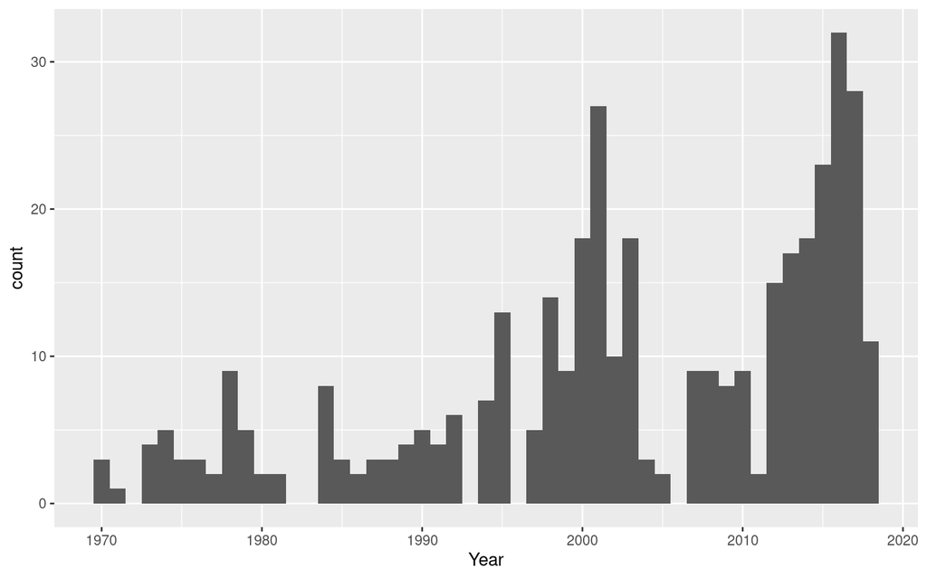

```r
# Create a histogram of CBRN incidents by year
ggplot(CBRNIncidents, aes(x=Year)) + geom_histogram(binwidth=1)
```

**EXERCISE 3. How many CBRN attacks are listed in this dataset**?  
**384 CBRN attacks are listed in this dataset.**

**EXERCISE 4. Based on the histogram, have there been CBRN attacks during every *decade* from 1970-2018**?  
**Yes, there have been CBRN attacks during every decade from 1970-2018.**

**EXERCISE 5. Have there been CBRN attacks during every *year* from 1970-2018**?  
**No, there haven’t been CBRN attacks during every year from 1970-2018.**

**EXERCISE 6. Have the number of CBRN attacks become more frequent in the most recent 10 years shown**?  
**As we can see from the height of the bars, the number of CBRN attacks have definitely become more frequent in the most recent 10 years.**

Now let’s count the number of incidents by `Region`, and color the histogram based on these regions. Remember that in order to have R count, we need to use the `summarise` function, which requires a `named argument`!. (What name am I giving it here?)

```r
# Calcuate the number of CBRN terrorist incidents in each region and view the results:
INC_per_Region <- summarise(group_by(CBRNIncidents, Region), count=n())

# Look at the result
kable(head(INC_per_Region)) %>%
  kable_styling(bootstrap_options = c("striped", "hover", "condensed", "responsive"), full_width = F, position = "left")
```

| Region | count |
| --- | --- |
| East Asia & Pacific | 40 |
| Europe & Central Asia | 67 |
| Latin America | 29 |
| Middle East & North Africa | 83 |
| North America | 51 |
| South Asia | 99 |

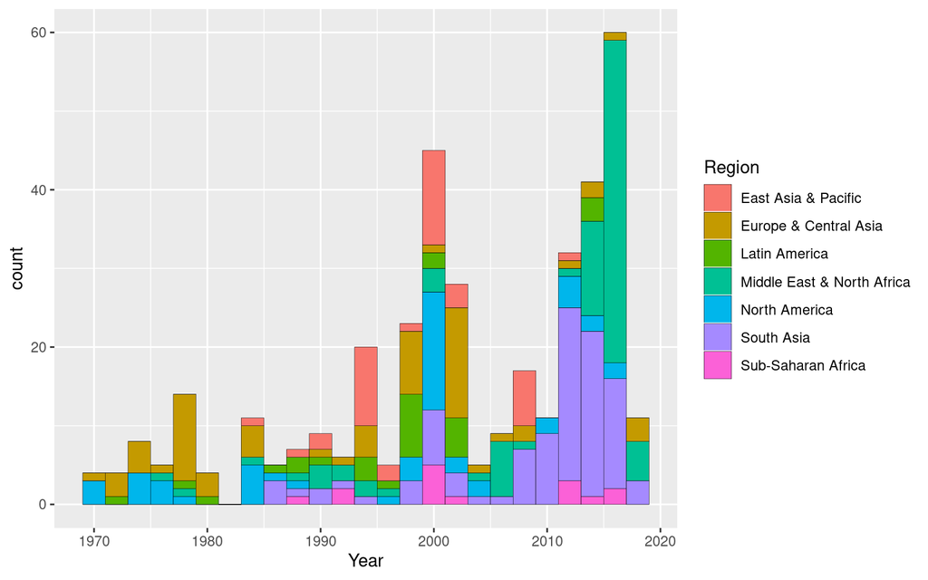

```r
# Color the CBRN incindents histogram by region, with a bin size of 2:
ggplot(CBRNIncidents, aes(x=Year, fill=Region)) + geom_histogram(binwidth=2, color = "black", size = 0.1)
```

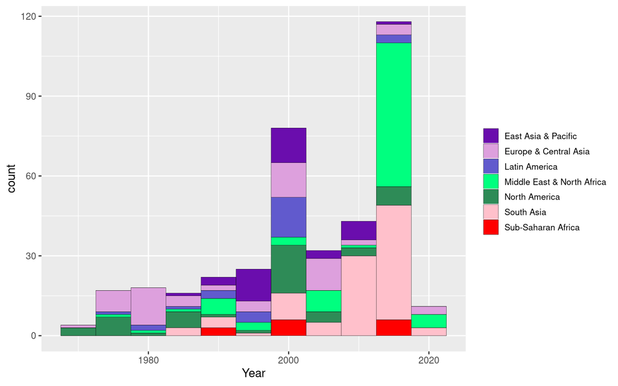

```r
# A modified version of the previous histogram using the custom colors and a binwidth of 5:
ggplot(CBRNIncidents, aes(x=Year, fill=Region)) +
geom_histogram(binwidth=5, color="black", size = 0.1) + scale_fill_manual(values=customColors) +
theme(legend.title=element_blank(), legend.key.size = unit(.5, "cm"),
legend.text=element_text(size=8))
```

**EXERCISE 7. Do CBRN attacks occur across the globe or only in some regions of the world**?  
**CBRN attacks seem to occur across the globe. Some regions are affected more severly than the others in some particular years, however, most parts of the world seem to have at least a few CBRN attacks.**

**EXERCISE 9. In what region(s) did most CBRN attacks occur during the 1970s? In what regions were the no CBRN attacks in the 70s**?  
**Europe and Central Asia and North America saw the most CBRN attacks during the 1970s. There were no CBRN attacks in the 70s in Sub Saharan Africa, South Asia and East Asia & Pacific.**

**EXERCISE 10. What noticeable feature is hidden by the histrogram with bin widths of 5 years**?  
**It hides the gaps in the graph.**

**EXERCISE 11. Where did most CBRN attacks occur between 2010-2018**?  
**Middle East & North America and South Asia saw the most CBRN attacks between 2010-2018.**

The following code can be used to count CBRN attacks by the intended target (`TargetType`), as well as the number and percentage of “successful” attacks for each target. In this data, a successful attack is defined as *“an act of terror was committed”*; it does not necessarily mean that the terrorists succeeded in their goal.

```r
# Create a table using counts of total incidents,
# total successful incidents by TargetType,
# and percent of successful incidents.
TOTAL_INCIDENT <- summarise(group_by(CBRNIncidents, TargetType), TotalCount=n(), SuccessfulCount=sum(Success),PercentSuccessful=SuccessfulCount/TotalCount)  %>%
  arrange(desc(SuccessfulCount))

kable(TOTAL_INCIDENT) %>%
  kable_styling(bootstrap_options = c("striped", "hover", "condensed", "responsive"), full_width = FALSE, position = "left")
```

| TargetType | TotalCount | SuccessfulCount | PercentSuccessful |
| --- | --- | --- | --- |
| Private Citizens & Property | 92 | 80 | 0.8695652 |
| Armed Forces | 74 | 67 | 0.9054054 |
| Government | 76 | 61 | 0.8026316 |
| Educational/Religious | 60 | 49 | 0.8166667 |
| Infrastructure | 34 | 25 | 0.7352941 |
| Business | 29 | 20 | 0.6896552 |
| Other/Unknown | 19 | 15 | 0.7894737 |

**EXERCISE 12. What target (`TargetType`) has been the site of the most CBRN attacks? How many attacks? Did this target also have the largest target success rate?**  
**Private Citizens & Property has been the site of the most CBRN attacks. There were 92 attacks. No, this target didn’t have the largest success rate.**

**EXERCISE 13. Which target had the second largest number of CBRN attacks? How many attacks? What was the success rate for these targets?**  
**Government has the second largest number of CBRN attacks with 76 total attacks. The success rate for those targets was 80.26%.**

**EXERCISE 14. Which target has the lowest percentage of successful attacks? Were there many attempts at these targets?**  
**Business has the lowest percentage of successful attacks. There were a total of 29 attacks on these targets.**

**EXERCISE 15. In general, do the targets with the smallest number of successes also have the smallest success percentages? Explain.**  
**Looking at the table, it looks like in general targets with the smallest number of successes also have the smallest success percentages.**

**EXERCISE 16. Modify the code above and determine the `AttackType` that is used most often in CBRN attacks. Do the most frequent types of attacks tend to correspond to the attacks with the largest percentage of successful attacks? Explain.**

```r
AttackTypes <- summarise(group_by(CBRNIncidents, AttackType), TotalCount=n(), SuccessfulCount=sum(Success),PercentSuccessful=SuccessfulCount/TotalCount)  %>%
  arrange(desc(SuccessfulCount))

kable(AttackTypes) %>%
  kable_styling(bootstrap_options = c("striped", "hover", "condensed", "responsive"), full_width = FALSE, position = "left")
```

| AttackType | TotalCount | SuccessfulCount | PercentSuccessful |
| --- | --- | --- | --- |
| Unarmed Assault | 254 | 211 | 0.8307087 |
| Bombing | 72 | 62 | 0.8611111 |
| Facility Attack | 33 | 25 | 0.7575758 |
| Assassination | 16 | 14 | 0.8750000 |
| Hostage Taking | 7 | 5 | 0.7142857 |
| Armed Assault | 2 | 0 | 0.0000000 |

**Unarmed assault was used most often in CBRN attacks. No, the most frequent types of attacks do not tend to correspond to the attacks with the largest percentage of successful attacks**

After looking at how many attacks occur, we may also be interested in knowing how dangerous these attacks are - that is, how many fatalities or injuries do they cause? We will first investigate fatalities (deaths), using `sum()` to count how many people died from CBRN-related attacks, and the percentage of attacks with CBRN weapons that caused fatalities. Then we will display the five most deadly attacks with information about their country and year, and make a scatterplot of fatalities with year on the *x*-axis.

```r
# Count the number of deaths from terrorist incidents (and have R ignore any missing/NA entries):
sum(CBRNIncidents$Fatalities, na.rm=TRUE)
```

```
## [1] 640
```

```r
# Count the number of attacks that resulted in at least one fatality -i.e. Fatalities more than zero, ignorning any missing/NA entries). Divide by the total number of attacks attempted.
sum(CBRNIncidents$Fatalities > 0, na.rm=TRUE) /sum(CBRNIncidents$Fatalities , na.rm=TRUE)
```

```
## [1] 0.1109375
```

**EXERCISE 17. How many fatalities were the result of CBRN terrorist attacks in the last 45 years**?  
**There were 640 fatalities from CBRN terrorist attacks in the last 45 years.**

```r
# Create a table with three columns (Year, Country, and number of fatalities).
# Sort the data by decreasing number of fatalities (largest to smallest).  Then
# print the 5 cases that resulted in the most deaths from terrorist attacks involving CBRN weapons.
CBNTable <- CBRNIncidents %>%
  select(Year, Country, Fatalities) %>%
  arrange(-Fatalities)

kable(head(CBNTable, 5)) %>%
  kable_styling(bootstrap_options = c("striped", "hover", "condensed", "responsive"), full_width = F, position = "left")
```

| Year | Country | Fatalities |
| --- | --- | --- |
| 2000 | Uganda | 200 |
| 1999 | Colombia | 65 |
| 2014 | Iraq | 36 |
| 2017 | Somalia | 32 |
| 2013 | Syria | 25 |

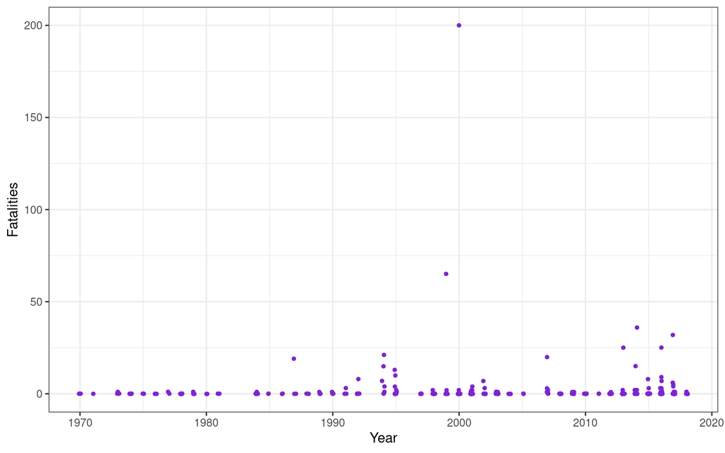

```r
# Create a scatterplot of fatalities vs. year
 jitter <- position_jitter(width = 0.1, height = 0.1)
ggplot(data=CBRNIncidents, aes(x=Year, y=Fatalities)) +
      geom_point(size=1, color = "purple3",position = jitter)   + theme_bw()
```

Note that I added some “jittering” to the points in order to see when there are multiple points lying on top of each other.

**EXERCISE 19. When, and where was the deadliest incident? How many deaths occurred? Is this incident noticeable on the scatterplot?**?  
**The deadliest incident was in Uganda in 2000. There were 200 deaths. The number of deaths for this incident was significantly higher than that for other incidents, making it a noticeable outlier in the scatterplot.**

- To find out more about the most deadly incidents, go to [the GTD website](http://www.start.umd.edu/gtd), http://www.start.umd.edu/gtd. Choose **Advanced Search** in the box on the left side of the screen. Use the filters to find what events caused the fatalities in Uganda in 2000.

**EXERCISE 20. When, and where was the CBRN attack that caused the *second* largest number of fatalities? How many deaths in this incident**?  
**It happened in the year 1999 in Colombia. There were 65 deaths.**

**EXERCISE 21. Use the GTD website to provide more details about the event in Columbia in exercise 20.**  
**On 12/12/1999, A naval base and police barracks were attacked by tear gas grenades in Jurado, Colombia. The incident killed 65 people.**

**EXERCISE 22. Which type of CBRN weapon was the most deadly? That is, use the GTD website to determine which of chemcial, biological, radiological or nuclear weapon types most often result in events with fatalities**? (chemical, biological, radiological or nuclear?)  
**Chemical weapons most often result in events with fatalities.**

**EXERCISE 23. Modify the code used for Exercises 17-19 (CHUNKS COUNTING DEATHS and MOST DEADLY ATTACKS) to evaluate the number of injuries (`Wounded`) caused by CBRN weapons.**  
**(a) Find the total number of wounded (taking into account missing/NA entries).**  
**(b) Determine the percentage of CBRN attacks that resulted in at least one injury.**  
**(c) Provide a table of the 10 CBRN attacks that caused the most injuries, with information about their country and year**.

```r
sum(CBRNIncidents$Wounded, na.rm=TRUE)
```

```
## [1] 15056
```

```r
sum(CBRNIncidents$Wounded > 0, na.rm=TRUE) /sum(CBRNIncidents$Wounded , na.rm=TRUE)
```

```
## [1] 0.01222104
```

```r
CBNTable1 <- CBRNIncidents %>%
  select(Year, Country, Wounded) %>%
  arrange(-Wounded)
kable(head(CBNTable1, 10)) %>%
  kable_styling(bootstrap_options = c("striped", "hover", "condensed", "responsive"), full_width = F, position = "left")
```

| Year | Country | Wounded |
| --- | --- | --- |
| 1995 | Japan | 5500 |
| 2016 | Iraq | 1500 |
| 1984 | United States | 751 |
| 1995 | Japan | 671 |
| 1994 | Japan | 500 |
| 2017 | Angola | 405 |
| 2018 | Afghanistan | 301 |
| 2007 | Iraq | 250 |
| 2013 | Afghanistan | 250 |
| 2012 | Afghanistan | 250 |

**EXERCISE 24. Create a scatterplot of *Wounded* by Year**.

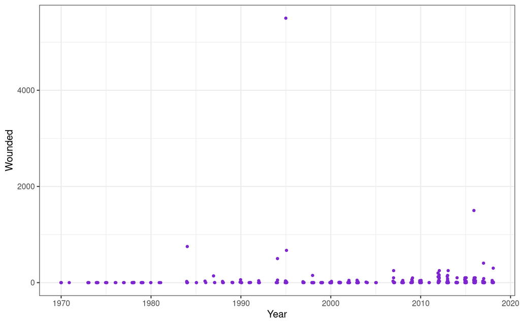

```r
 jitter <- position_jitter(width = 0.1, height = 0.1)
ggplot(data=CBRNIncidents, aes(x=Year, y=Wounded)) +
      geom_point(size=1, color = "purple3",position = jitter)   + theme_bw()
```

**EXERCISE 25. From the statistics and graph, are CBRN attacks more likely to *injure* people or *cause fatalities*** ?  
**It seems like CBRN attacks are more likely to injure people than cause fatalities.**

**EXERCISE 26. Use the advanced search at the GTD website to find the event(s) which caused the 5500 injuries in the attack listed in the first row of your table in exercise 23**.  
**The event happened on 1995-03-20 in Tokyo, Japan. It was a successful unarmed assault. The weapon type was Chemical. The target type was transportation and Perpetrator Group was Aum Shinri Kyo.**

**EXERCISE 27. Describe the 1984 US attack that caused 751 injuries?**  
**The attack happened on 1984-09-20 in Dalles, Oregon, United States. It was a successful unarmed assault. The weapon type used was biological. The target type was business and Perpetrator group was Rajneeshees.**

These attacks reinforce what we found with fatalities: most successful attacks with CBRN weapons use chemical weapons<sup>2</sup>, even though biological, radiological, and nuclear weapons threaten to do damage on a massive scale.

We’ve learned that attacks with sophisticated weapons do happen, and on occasion they can cause a considerable number of deaths and injuries. However, we have yet to see any attacks using CBRN weapons such as plagues, dirty bombs, and nuclear strikes that have caused mass injuries or fatalities. In the next section we compare CBRN weapons to other types of weapons.